# task12

Paulius Kostickis

Sunday, April 24, 2016

1. For this exercise, use the monthly Australian short-term overseas visitors data, May 1985–April 2005. (Data set: visitors in expsmooth package.)

#### (a) Use ets to find the best model for these data and record the

#### training set RMSE. You should find that the best model is ETS(M,A,M).

Pagal ETS() randame geriausią modelį:

```r
mod=ets(data)

mod
```

```
## ETS(M,A,M)
##
## Call:
##  ets(y = data)
##
##   Smoothing parameters:
##     alpha = 0.6244
##     beta  = 1e-04
##     gamma = 0.1832
##
##   Initial states:
##     l = 86.3534
##     b = 2.0306
##     s=0.942 1.076 1.0515 0.9568 1.3621 1.1157
##            1.011 0.8294 0.9336 1.0017 0.8649 0.8554
##
##   sigma:  0.0515
##
##      AIC     AICc      BIC
## 2598.193 2600.632 2653.883
```

Kaip matome parinko ETS(M,A,M).

#### (b) We will now check how much larger the one-step RMSE is on out-of-sample data using time series cross-validation. The following code will compute the result, beginning with four years of data in the training set.

```r
k <- 48 # minimum size for training set
n <- length(data) # Total number of observations
e <- data*NA # Vector to record one-step forecast errors
for(i in k:(n-1))
{
train <- ts(data[1:i],freq=12)            #sukuriami train duomenys
fit <- ets(train, "MAM", damped=FALSE)    #sukuriamas geriausias metodas su ets(M,A,M) train duomenyse
fc <- forecast(fit,h=1)$mean              #prognozė vienui žingsniui į priekį nuo paskutintos train reikšmės
e[i] <- data[i+1]-fc                      #apskaičiuojama to žingsnio paklaida ir įdedama reikšmė į atitinkamą vektoriaus vietą
}
sqrt(mean(e^2,na.rm=TRUE))                #RMSE prognozės naudojant training setus.
```

```
## [1] 18.08962
```

#### (c) What would happen in the above loop if I had set train <- visitors[1:i]?

Meta klaidą, nes jei norime apskaičiuoti sezoniškumą, reikia turėti time-series duomenų klasę (ets(M,A,M) -> multiplikatyvus sezoniškumas).

#### (d) Plot e. What do you notice about the error variances?

Matome, kad nuo 1998 metų ryškiai pasikeitė liekanos - jų variacija smarkiai padidėjo.

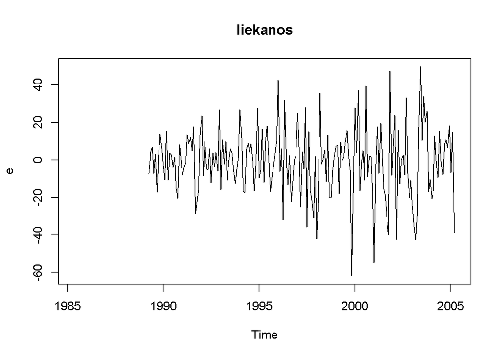

```r
plot(e,main="liekanos")
```

#### Why does this occur?

Matome, kad nuo 1998 metų ryškiai pasikeitė duomenų trendas ir sezoniškumas ir todėl prognozės klaidos smarkiai išaugo, nes prognozė prisitaikiusi prie senesnių duomenų ir nebūtinai geriausiu metodu, t.y. modelis buvo skaičiuotas tik ETS(M,A,M).

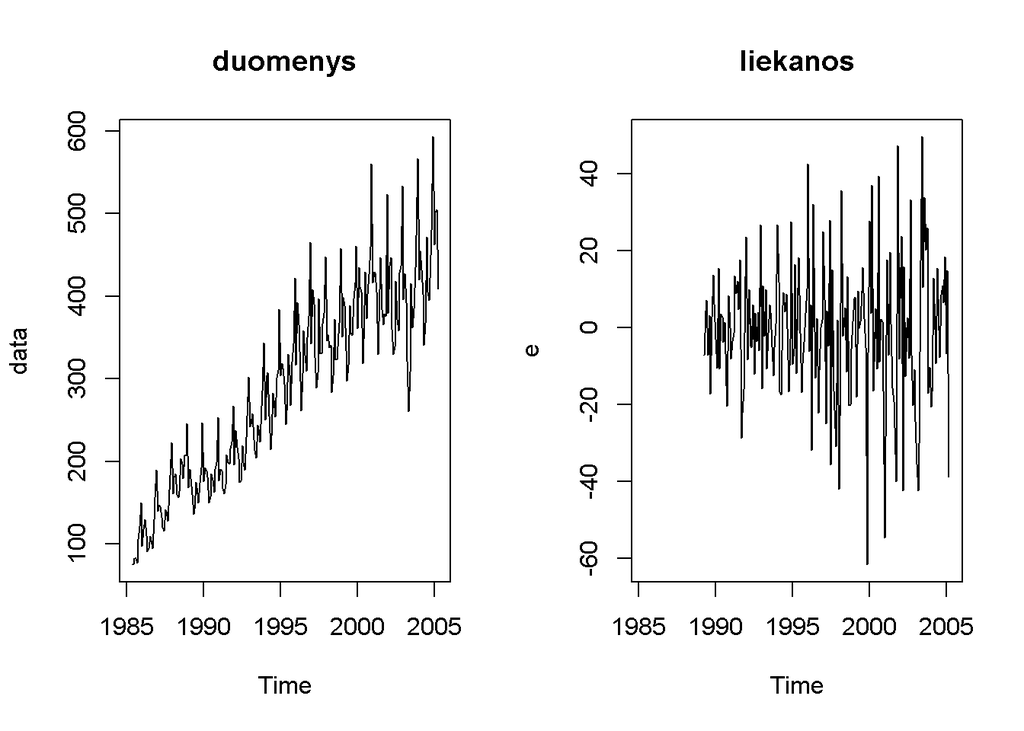

```r
par(mfrow=c(1,2))
plot(data,main="duomenys")
plot(e,main="liekanos")
```

5. How does this problem bias the comparison of the RMSE values from (1a) and (1b)? (Hint: think about the effect of the missing values in e.)

Žvelgiant į paklaidų RMSE rodiklį prognozėse:

RMSE iš (1a)

```r
RMSEa = summary(mod)[2]
```

```
## ETS(M,A,M)
##
## Call:
##  ets(y = data)
##
##   Smoothing parameters:
##     alpha = 0.6244
##     beta  = 1e-04
##     gamma = 0.1832
##
##   Initial states:
##     l = 86.3534
##     b = 2.0306
##     s=0.942 1.076 1.0515 0.9568 1.3621 1.1157
##            1.011 0.8294 0.9336 1.0017 0.8649 0.8554
##
##   sigma:  0.0515
##
##      AIC     AICc      BIC
## 2598.193 2600.632 2653.883
##
## Training set error measures:
##                      ME   RMSE     MAE        MPE     MAPE      MASE
## Training set -0.9564743 15.847 11.5215 -0.4307078 4.075378 0.4254781
##                    ACF1
## Training set 0.02434609
```

```r
RMSEa
```

```
## [1] 15.847
```

RMSE iš (1b)

```r
RMSEb = sqrt(mean(e^2,na.rm=TRUE))
RMSEb
```

```
## [1] 18.08962
```

Matome, kad iš 1a dalies rodiklis geresnis už 1b dalies RMSE, nors 1b dalyje, mažiau paklaidų buvo apskaičiuota. 1b dalyje prognozė buvo atliekama iš mažesnių imčių ir nežinant prognozuojamų duomenų, todėl smarkiai padidėjo RMSE.

6. In practice, we will not know that the best model on the whole data set is ETS(M,A,M) until we observe all the data. So a more realistic analysis would be to allow ets to select a different model each time through the loop. Calculate the RMSE using this approach. (Warning: it will take a while as there are a lot of models to fit.)

```r
for(i in k:(n-1)){
  train <- ts(data[1:i],freq=12)        #sukuriami train duomenys
  fit <- ets(train)                     #sukuriamas geriausias metodas su ets(M,A,M) train duomenyse

  fc <- forecast(fit,h=1)$mean          #prognozė vienui žingsniui į priekį nuo paskutintos train reikšmės

  e[i] <- data[i+1]-fc                  #apskaičiuojama to žingsnio paklaida ir įdedama reikšmė į
                                        #atitinkamą vektoriaus vietą
  }
RMSEf=sqrt(mean(e^2,na.rm=TRUE))        #RMSE prognozės naudojant training set'e.
```

#### (g) How does the RMSE computed in (1f) compare to that computed in (1b)? Does the re-selection of a model at each step make much difference?

Nėra matomas didelis skirtumas tarp f ir b dalies:

```r
RMSEb     #b) dalies RMSE
```

```
## [1] 18.08962
```

```r
RMSEf     #f) dalies RMSE
```

```
## [1] 18.47088
```